# Project 1: Reproducible Research

JADraves

June 26, 2019

## Introduction

It is now possible to collect a large amount of data about personal movement using activity monitoring devices such as a Fitbit, Nike Fuelband, or Jawbone Up. These type of devices are part of the “quantified self” movement - a group of enthusiasts who take measurements about themselves regularly to improve their health, to find patterns in their behavior, or because they are tech geeks. But these data remain under-utilized both because the raw data are hard to obtain and there is a lack of statistical methods and software for processing and interpreting the data.

This assignment makes use of data from a personal activity monitoring device. This device collects data at 5 minute intervals through out the day. The data consists of two months of data from an anonymous individual collected during the months of October and November, 2012 and include the number of steps taken in 5 minute intervals each day.

The data for this assignment can be downloaded from the course web site:

Dataset: Activity monitoring data [52K] The variables included in this dataset are:

steps: Number of steps taking in a 5-minute interval (missing values are coded as NA. date: The date on which the measurement was taken in YYYY-MM-DD format. interval: Identifier for the 5-minute interval in which measurement was taken.

The dataset is stored in a comma-separated-value (CSV) file and there are a total of 17,568 observations in this dataset.

## Section 1. Loading and Preprocessing the Data

```r
#Data was downloaded from course site, stored in working directory, and read in using the read.csv()fuction as
#instructed.  Reading directly from the site maybe a better option.

activity <- read.csv("activity.csv")
```

## Section 2. What is the mean total number of steps taken per day?

#### Calculate the total number of steps taken per day.

#### Make a histogram of the total number of steps taken per day.

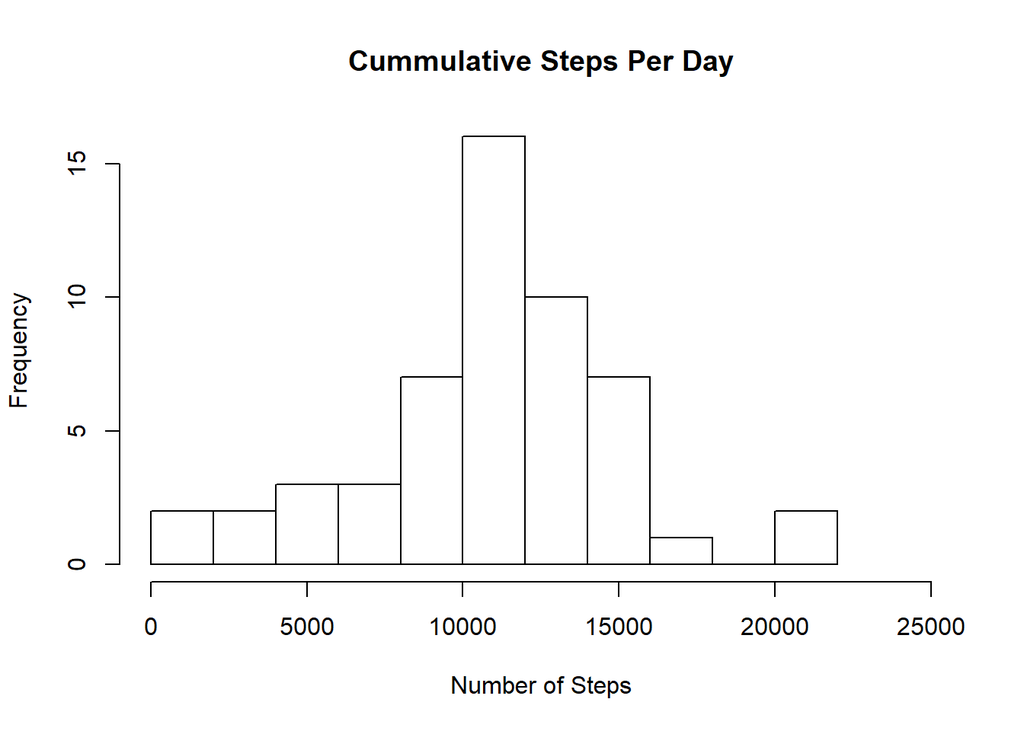

```r
SumStepsDaily <- tapply(activity$steps, activity$date, sum)

MeanDailySteps <- mean(SumStepsDaily, na.rm=TRUE)
MedianDailySteps <- median(SumStepsDaily, na.rm=TRUE)

hist(SumStepsDaily, xlab="Number of Steps", xlim=c(0, 25000), main="Cummulative Steps Per Day", breaks=10)
```

## Section 3. What is the average daily activity pattern?

#### Make a time series plot of the 5-minute interval (x-axis) and the average number of steps taken, averaged across all days (y-axis)

#### Which 5-minute interval, on average across all the days in the dataset, contains the maximum number of steps?

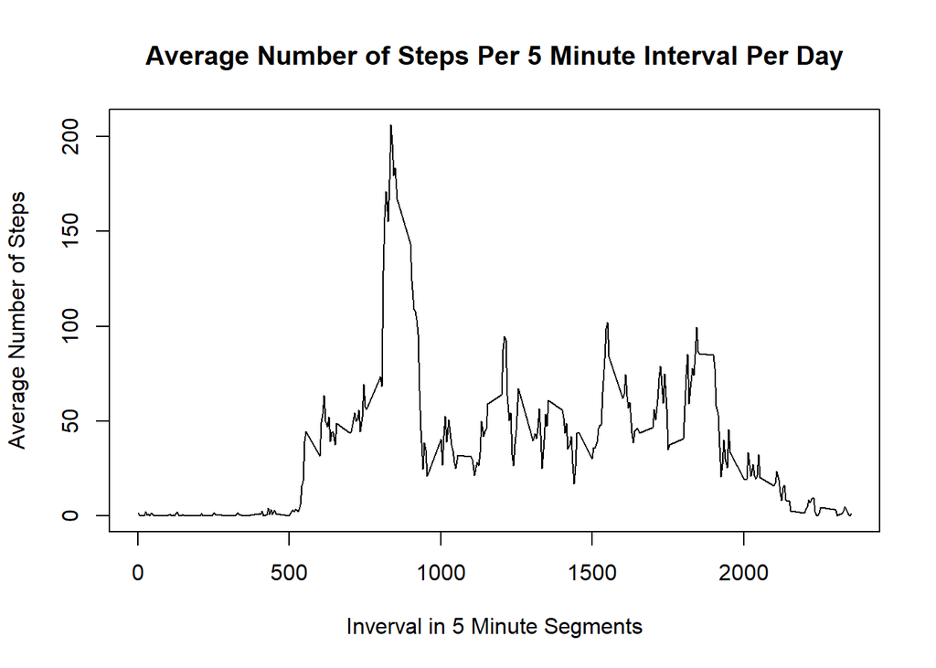

```r
library(plyr)
library(stats)
MeanStepsPerInterval <- ddply(activity, .(interval), summarize, StepAvg = mean(steps, na.rm=TRUE))
plot(MeanStepsPerInterval$interval, MeanStepsPerInterval$StepAvg, type="l",
     xlab="Inverval in 5 Minute Segments", ylab="Average Number of Steps",
     main="Average Number of Steps Per 5 Minute Interval Per Day")
```

```r
MaxSteps <- max(MeanStepsPerInterval$StepAvg)
IntervalwithMaxSteps <- MeanStepsPerInterval[MeanStepsPerInterval$StepAvg==MaxSteps,1]
```

### The maximum number of steps is 206.1698113 and the maximum number of steps occurs in the interval begining at minute 835.

## Section 4. Imputing missing values. Note that there are a number of days/intervals where there are missing values, NA. The presence of missing days may introduce bias into some calculations or summaries of the data.

#### Devise a strategy for filling in all of the missing values in the dataset. The strategy does not need to be sophisticated. For example, you could use the mean/median for that day, or the mean for that 5-minute interval, etc.

#### Create a new dataset that is equal to the original dataset but with the missing data filled in.

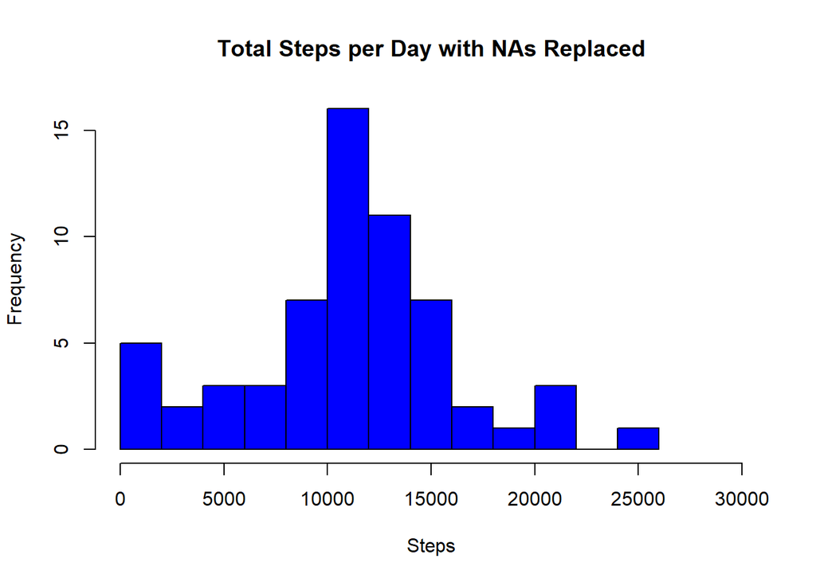

```r
# Note that imputing data can lead to problems in the analysis and should therefor be done only sparing.
# Create copies of data frames to preserve data.
FileActivity <- activity
FileMSPI <- MeanStepsPerInterval

TotalNAs <- sum(is.na(FileActivity$steps))
ActAvemerge = merge(FileActivity, FileMSPI, by="interval")

NAIndexFile = which(is.na(FileActivity$steps))
#NA's will be replaced with interval averages.  This will keep the distribution approximatley "the same"
FileActivity[NAIndexFile,"steps"] = ActAvemerge[NAIndexFile,"StepAvg"]

SumStepsDaily2 <- tapply(FileActivity$steps, activity$date, sum)

MeanDailySteps2 <- mean(SumStepsDaily2, na.rm=TRUE)
MedianDailySteps2 <- median(SumStepsDaily2, na.rm=TRUE)

hist(SumStepsDaily2, breaks=10, xlab="Steps", xlim = c(0,30000), main = "Total Steps per Day with NAs Replaced", col="Blue")
```

## Section 5. Are there differences in activity patterns between weekdays and weekends?

#### For this part the weekdays() function may be of some help here. Use the dataset with the filled-in missing values for this part.

#### Create a new factor variable in the dataset with two levels - “weekday” and “weekend” indicating whether a given date is a weekday or weekend day.

#### Make a panel plot containing a time series plot of the 5-minute interval (x-axis) and the average number of steps taken, averaged across all weekday days or weekend days (y-axis). See the README file in the GitHub repository to see an example of what this plot should look like using simulated data.

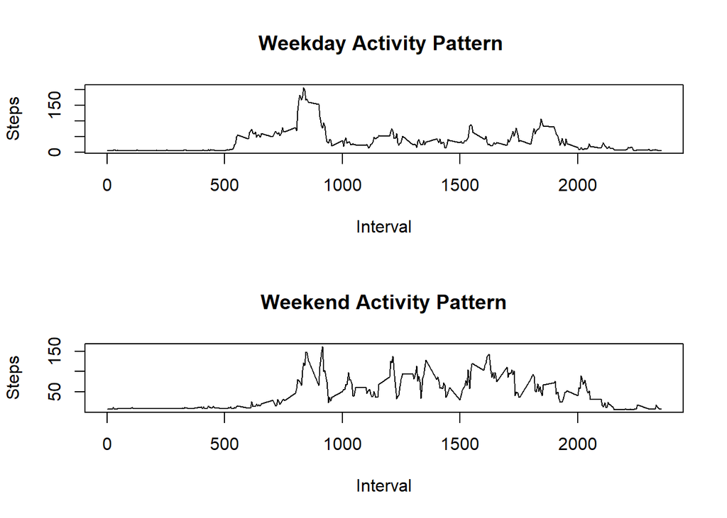

```r
FileActivity2 <- FileActivity
FileActivity2$day <- ifelse(weekdays(as.Date(FileActivity2$date)) == "Saturday" | weekdays(as.Date(FileActivity2$date)) == "Sunday", "Weekend", "Weekday")

FileActivityWeekend <- tapply(FileActivity2[FileActivity2$day =="Weekend", ]$steps, FileActivity2[FileActivity2$day=="Weekend", ]$interval, mean)

FileActivityWeekday <- tapply(FileActivity2[FileActivity2$day =="Weekday", ]$steps, FileActivity2[FileActivity2$day=="Weekday", ]$interval, mean)

# Stack the plots
par(mfrow=c(2,1))

# Weekday activity
plot(as.numeric(names(FileActivityWeekday)),
     FileActivityWeekday, xlab = "Interval", ylab = "Steps",
     main = "Weekday Activity Pattern ", type = "l")

# Weekend activity
plot(as.numeric(names(FileActivityWeekend)),
     FileActivityWeekend, xlab = "Interval", ylab = "Steps",
     main = "Weekend Activity Pattern", type = "l")
```

### Inspection and comparison of the plots suggests that there is a difference between weekend and weekday step activity.